# Case study on text classification

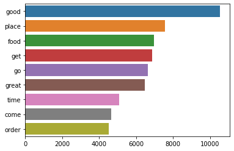

```python
corpus=[]
corpus=[word for i in YELP_sub.Token[YELP_sub.stars==4] for word in i]

counter=Counter(corpus)
most=counter.most_common()

X, Y= [], []
for word,count in most[:10]:
    X.append(word)
    Y.append(count)

sns.barplot(x=Y,y=X)
```

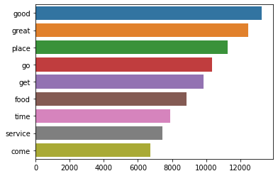

```python
corpus=[]
corpus=[word for i in YELP_sub.Token[YELP_sub.stars==5] for word in i]

counter=Counter(corpus)
most=counter.most_common()

X, Y= [], []
for word,count in most[:10]:
    X.append(word)
    Y.append(count)

sns.barplot(x=Y,y=X)
```

#### Ngram exploration

Looking at most frequent n-grams can give you a better understanding of the context in which the word was used.

```python
def get_top_ngram(corpus, n=None):
    vec = CountVectorizer(ngram_range=(n, n)).fit(corpus)
    bag_of_words = vec.transform(corpus)
    sum_words = bag_of_words.sum(axis=0)
    words_freq = [(word, sum_words[0, idx])
                  for word, idx in vec.vocabulary_.items()]
    words_freq =sorted(words_freq, key = lambda x: x[1], reverse=True)
    return words_freq[:10]
```

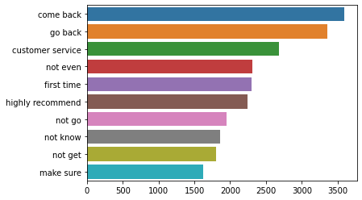

```python
top_n_bigrams=get_top_ngram(YELP_sub.Token.apply(" ".join),2)[:10]
x,y=map(list,zip(*top_n_bigrams))
sns.barplot(x=y,y=x)
```

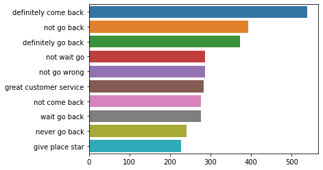

```python
top_n_trigrams=get_top_ngram(YELP_sub.Token.apply(" ".join),3)[:10]
x,y=map(list,zip(*top_n_trigrams))
sns.barplot(x=y,y=x)
```

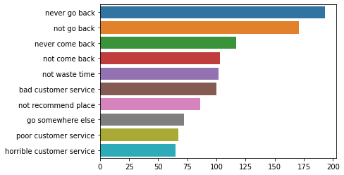

```python
top_n_trigrams=get_top_ngram(YELP_sub.Token[YELP_sub.stars==1].apply(" ".join),3)[:10]
x,y=map(list,zip(*top_n_trigrams))
sns.barplot(x=y,y=x)
```

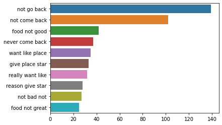

```python
top_n_trigrams=get_top_ngram(YELP_sub.Token[YELP_sub.stars==2].apply(" ".join),3)[:10]
x,y=map(list,zip(*top_n_trigrams))
sns.barplot(x=y,y=x)
```

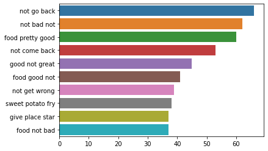

```python
top_n_trigrams=get_top_ngram(YELP_sub.Token[YELP_sub.stars==3].apply(" ".join),3)[:10]
x,y=map(list,zip(*top_n_trigrams))
sns.barplot(x=y,y=x)
```

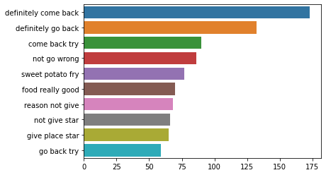

```python
top_n_trigrams=get_top_ngram(YELP_sub.Token[YELP_sub.stars==4].apply(" ".join),3)[:10]
x,y=map(list,zip(*top_n_trigrams))
sns.barplot(x=y,y=x)
```

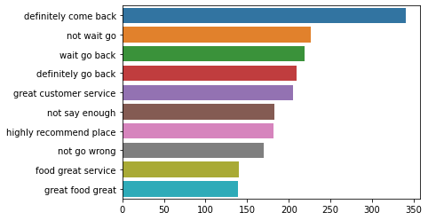

```python
top_n_trigrams=get_top_ngram(YELP_sub.Token[YELP_sub.stars==5].apply(" ".join),3)[:10]
x,y=map(list,zip(*top_n_trigrams))
sns.barplot(x=y,y=x)
```

#### Topic modeling exploration with pyLDAvis

Topic modeling is the process of using unsupervised learning techniques to extract the main topics that occur in a collection of documents.

```python
def preprocess_text(df):
    corpus=[]
    lem=WordNetLemmatizer()
    for textList in tqdm(YELP_sub.Token):
        words=[lem.lemmatize(w) for w in textList]
        corpus.append(words)
    return corpus

corpus=preprocess_text(YELP_sub)
```

```python
dic=gensim.corpora.Dictionary(corpus)
bow_corpus = [dic.doc2bow(doc) for doc in corpus]
```

Latent Dirichlet Allocation (LDA) represents each document by the distribution of topics and each topic is represented by the distribution of words.

```python
lda_model = gensim.models.LdaMulticore(bow_corpus,
                                   num_topics = 5,
                                   id2word = dic,
                                   passes = 10,
                                   workers = 2)
lda_model.show_topics()
```

```
[(0,
  '0.027*"store" + 0.016*"shop" + 0.012*"love" + 0.011*"great" + 0.008*"und" + 0.008*"find" + 0.008*"amazing" + 0.008*"die" + 0.008*"selection" + 0.008*"price"'),
 (1,
  '0.023*"not" + 0.012*"place" + 0.011*"room" + 0.011*"get" + 0.010*"go" + 0.009*"great" + 0.009*"good" + 0.007*"nice" + 0.007*"time" + 0.006*"see"'),
 (2,
  '0.034*"not" + 0.015*"go" + 0.014*"get" + 0.012*"time" + 0.010*"service" + 0.009*"say" + 0.008*"take" + 0.008*"work" + 0.008*"tell" + 0.008*"come"'),
 (3,
  '0.018*"good" + 0.017*"not" + 0.013*"food" + 0.013*"place" + 0.012*"great" + 0.009*"try" + 0.009*"get" + 0.008*"come" + 0.008*"chicken" + 0.008*"order"'),
 (4,
  '0.042*"not" + 0.026*"food" + 0.019*"good" + 0.017*"order" + 0.016*"place" + 0.013*"go" + 0.013*"get" + 0.010*"come" + 0.010*"service" + 0.009*"time"')]
```

```python
import pyLDAvis.gensim_models as gensimvis

pyLDAvis.enable_notebook()
vis = gensimvis.prepare(lda_model, bow_corpus, dic)
vis
```

[interactive chart not shown]

#### Wordcloud

Wordcloud is a great way to represent text data: the size and color of each word that appears in the wordcloud indicate it’s frequency or importance.

```python
def show_wordcloud(data):
    wordcloud = WordCloud(
        background_color='white',
        stopwords=stopwords,
        max_words=100,
        max_font_size=30,
        scale=3,
        random_state=1)

    wordcloud=wordcloud.generate(str(data))

    fig = plt.figure(1, figsize=(12, 12))
    plt.axis('off')

    plt.imshow(wordcloud)
    plt.show()
```

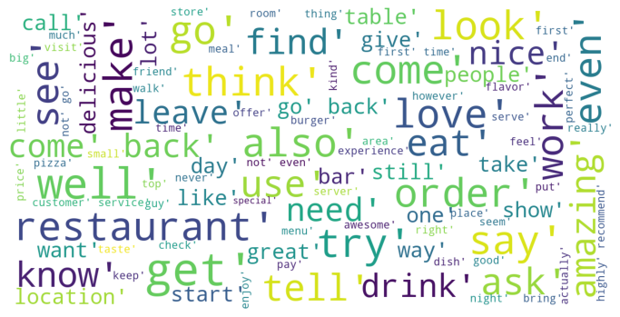

```python
corpus=[]
corpus=[word for i in YELP_sub.Token for word in i]

show_wordcloud(corpus)
```

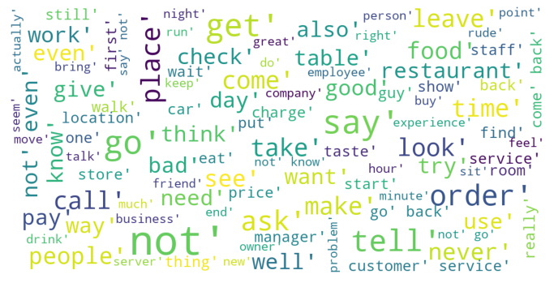

```python
corpus=[]
corpus=[word for i in YELP_sub.Token[YELP_sub.stars==1] for word in i]

show_wordcloud(corpus)
```

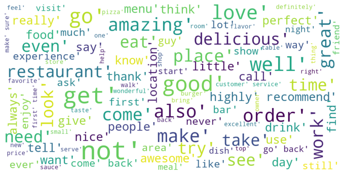

```python
corpus=[]
corpus=[word for i in YELP_sub.Token[YELP_sub.stars==5] for word in i]

show_wordcloud(corpus)
```

## Text Classification

```python
YELP_sel=YELP[(YELP.Token.str.len()>10)&(YELP.Token.str.len()<75)][["stars", "textToken"]]
```

```python
labels = YELP_sel.stars.tolist()
category_list = YELP_sel.stars.unique()
X_train, X_split, y_train, y_split = train_test_split(YELP_sel.textToken.tolist(), labels, train_size=0.85, stratify=labels, random_state=123)
```

```python
labels = y_split
category_list = list(np.unique(y_split))
X_test_, X_val_, y_test_, y_val_ = train_test_split(X_split, y_split, train_size=0.50, stratify=labels, random_state=123)
```

```python
YELP_train=pd.DataFrame(columns=["stars", "textToken"])
YELP_train["stars"]=y_train
YELP_train["textToken"]=X_train

chunk=int(YELP_train.shape[0]/100)
YELP_dicTrain={}
for n in tqdm(range((YELP_train.shape[0] // chunk))):
    if len(str(n))==1:
        N="0"+str(n)
    else:
        N=str(n)
    fileName=N+"subSet"
    df_temp=YELP_train.iloc[n*chunk:(n+1)*chunk]
    df_temp.reset_index(drop=True, inplace=True)
    YELP_dicTrain[fileName]=df_temp

YELP_dicTrain.keys()
```

```
dict_keys(['00subSet', '01subSet', '02subSet', '03subSet', '04subSet', '05subSet', '06subSet', '07subSet', '08subSet', '09subSet', '10subSet', '11subSet', '12subSet', '13subSet', '14subSet', '15subSet', '16subSet', '17subSet', '18subSet', '19subSet', '20subSet', '21subSet', '22subSet', '23subSet', '…
```

```python
vectorizer = HashingVectorizer(
    decode_error="ignore", n_features=2 ** 18, alternate_sign=False
)

tick = time.time()
X_test = vectorizer.transform(X_test_)
vectorizing_time = time.time() - tick

y_test=np.asarray(y_test_, dtype=int)

X_val = vectorizer.transform(X_val_)
y_val=np.asarray(y_val_, dtype=int)

all_classes = np.unique(y_test)
all_classes
```

```
array([1, 2, 3, 4, 5])
```

```python
# test data statistics
test_stats = {"n_test": 0}
test_stats["n_test"] += len(y_test)
print("Test set is %d documents " % (len(y_test)))
```

```
Test set is 295073 documents
```

```python
# Here are some classifiers that support the `partial_fit` method
partial_fit_classifiers = {
    "SGD_svm": SGDClassifier(loss='hinge'),
    "SGD_log": SGDClassifier(loss='log'),
    "SGD_mHuber": SGDClassifier(loss='modified_huber'),
    "SGD_sHinge": SGDClassifier(loss='squared_hinge'),
    "Perceptron": Perceptron(),
    "NB Multinomial": MultinomialNB(alpha=0.01),
    "NB Complement": ComplementNB(alpha=0.01),
    "Passive-Aggressive": PassiveAggressiveClassifier(),
}

cls_stats = {}
for cls_name in partial_fit_classifiers:
    stats = {
        "n_train": 0,
        "accuracy": 0.0,
        "accuracy_history": [(0, 0)],
        "t0": time.time(),
        "runtime_history": [(0, 0)],
        "total_fit_time": 0.0,
    }
    cls_stats[cls_name] = stats
```

```python
def progress(cls_name, stats):
    """Report progress information, return a string."""
    duration = time.time() - stats["t0"]
    s = "%20s classifier : \t" % cls_name
    s += "%(n_train)6d train docs " % stats
    s += "%(n_test)6d test docs " % test_stats
    s += "accuracy: %(accuracy).3f " % stats
    s += "in %.2fs (%5d docs/s)" % (duration, stats["n_train"] / duration)
    return s

total_vect_time = 0.0
```

```python
predCls={
    "SGD_svm": np.zeros((1,1)),
    "SGD_log": np.zeros((1,1)),
    "SGD_mHuber": np.zeros((1,1)),
    "SGD_sHinge": np.zeros((1,1)),
    "Perceptron": np.zeros((1,1)),
    "NB Multinomial": np.zeros((1,1)),
    "NB Complement": np.zeros((1,1)),
    "Passive-Aggressive": np.zeros((1,1)),
}
```

```python
for i, subSet in tqdm(enumerate(YELP_dicTrain.keys())):
    DF_tmp=YELP_dicTrain[subSet]

    X_train_text=list(DF_tmp.textToken)

    y_train=np.asarray(DF_tmp.stars, dtype=int)

    tick = time.time()
    X_train = vectorizer.transform(X_train_text)
    total_vect_time += time.time() - tick

    for cls_name, cls in partial_fit_classifiers.items():
        tick = time.time()
        # update estimator with examples in the current mini-batch
        cls.partial_fit(X_train, y_train, classes=all_classes)

        # accumulate test accuracy stats
        cls_stats[cls_name]["total_fit_time"] += time.time() - tick
        cls_stats[cls_name]["n_train"] += X_train.shape[0]
        tick = time.time()
        cls_stats[cls_name]["accuracy"] = cls.score(X_test, y_test)
        cls_stats[cls_name]["prediction_time"] = time.time() - tick
        acc_history = (cls_stats[cls_name]["accuracy"], cls_stats[cls_name]["n_train"])
        cls_stats[cls_name]["accuracy_history"].append(acc_history)
        run_history = (
            cls_stats[cls_name]["accuracy"],
            total_vect_time + cls_stats[cls_name]["total_fit_time"],
        )
        cls_stats[cls_name]["runtime_history"].append(run_history)

        Print=33
        if i % Print == 0:
            print(progress(cls_name, cls_stats[cls_name]))
        if i == len(YELP_dicTrain)-1:
            print(cls_name)
            predCls[cls_name]=cls.predict(X_val)
    if i % Print == 0:
        print("\n")
```

```
0it [00:00, ?it/s]
```

```
             SGD_svm classifier : 	 33441 train docs 295073 test docs accuracy: 0.610 in 2.80s (11944 docs/s)
             SGD_log classifier : 	 33441 train docs 295073 test docs accuracy: 0.625 in 3.22s (10376 docs/s)
          SGD_mHuber classifier : 	 33441 train docs 295073 test docs accuracy: 0.600 in 3.67s ( 9111 docs/s)
          SGD_sHinge classifier : 	 33441 train docs 295073 test docs accuracy: 0.563 in 4.14s ( 8086 docs/s)
          Perceptron classifier : 	 33441 train docs 295073 test docs accuracy: 0.530 in 4.68s ( 7141 docs/s)
      NB Multinomial classifier : 	 33441 train docs 295073 test docs accuracy: 0.576 in 5.12s ( 6532 docs/s)
       NB Complement classifier : 	 33441 train docs 295073 test docs accuracy: 0.588 in 5.77s ( 5797 docs/s)
```

```
1it [00:05,  5.95s/it]
```

```
  Passive-Aggressive classifier : 	 33441 train docs 295073 test docs accuracy: 0.610 in 6.27s ( 5329 docs/s)
```

```
33it [02:45,  4.59s/it]
```

```
             SGD_svm classifier : 	1136994 train docs 295073 test docs accuracy: 0.615 in 167.94s ( 6770 docs/s)
             SGD_log classifier : 	1136994 train docs 295073 test docs accuracy: 0.626 in 168.48s ( 6748 docs/s)
          SGD_mHuber classifier : 	1136994 train docs 295073 test docs accuracy: 0.650 in 168.94s ( 6730 docs/s)
          SGD_sHinge classifier : 	1136994 train docs 295073 test docs accuracy: 0.553 in 169.40s ( 6711 docs/s)
          Perceptron classifier : 	1136994 train docs 295073 test docs accuracy: 0.579 in 169.84s ( 6694 docs/s)
      NB Multinomial classifier : 	1136994 train docs 295073 test docs accuracy: 0.608 in 170.25s ( 6678 docs/s)
       NB Complement classifier : 	1136994 train docs 295073 test docs accuracy: 0.610 in 170.67s ( 6661 docs/s)
```

```
34it [02:50,  4.94s/it]
```

```
  Passive-Aggressive classifier : 	1136994 train docs 295073 test docs accuracy: 0.623 in 171.15s ( 6643 docs/s)
```

```
66it [05:18,  4.52s/it]
```

```
             SGD_svm classifier : 	2240547 train docs 295073 test docs accuracy: 0.619 in 321.31s ( 6973 docs/s)
             SGD_log classifier : 	2240547 train docs 295073 test docs accuracy: 0.627 in 321.76s ( 6963 docs/s)
          SGD_mHuber classifier : 	2240547 train docs 295073 test docs accuracy: 0.651 in 322.13s ( 6955 docs/s)
          SGD_sHinge classifier : 	2240547 train docs 295073 test docs accuracy: 0.549 in 322.51s ( 6947 docs/s)
          Perceptron classifier : 	2240547 train docs 295073 test docs accuracy: 0.550 in 322.88s ( 6939 docs/s)
      NB Multinomial classifier : 	2240547 train docs 295073 test docs accuracy: 0.608 in 323.38s ( 6928 docs/s)
       NB Complement classifier : 	2240547 train docs 295073 test docs accuracy: 0.611 in 323.69s ( 6921 docs/s)
```

```
67it [05:23,  4.65s/it]
```

```
  Passive-Aggressive classifier : 	2240547 train docs 295073 test docs accuracy: 0.614 in 324.07s ( 6913 docs/s)
```

```
99it [08:08,  4.96s/it]
```

```
             SGD_svm classifier : 	3344100 train docs 295073 test docs accuracy: 0.617 in 490.64s ( 6815 docs/s)
SGD_svm
             SGD_log classifier : 	3344100 train docs 295073 test docs accuracy: 0.627 in 491.44s ( 6804 docs/s)
SGD_log
          SGD_mHuber classifier : 	3344100 train docs 295073 test docs accuracy: 0.653 in 492.09s ( 6795 docs/s)
SGD_mHuber
          SGD_sHinge classifier : 	3344100 train docs 295073 test docs accuracy: 0.548 in 492.62s ( 6788 docs/s)
SGD_sHinge
          Perceptron classifier : 	3344100 train docs 295073 test docs accuracy: 0.569 in 493.23s ( 6780 docs/s)
Perceptron
      NB Multinomial classifier : 	3344100 train docs 295073 test docs accuracy: 0.608 in 493.81s ( 6771 docs/s)
NB Multinomial
       NB Complement classifier : 	3344100 train docs 295073 test docs accuracy: 0.612 in 494.37s ( 6764 docs/s)
NB Complement
  Passive-Aggressive classifier : 	3344100 train docs 295073 test docs accuracy: 0.620 in 495.00s ( 6755 docs/s)
Passive-Aggressive
```

```
100it [08:14,  4.95s/it]
```

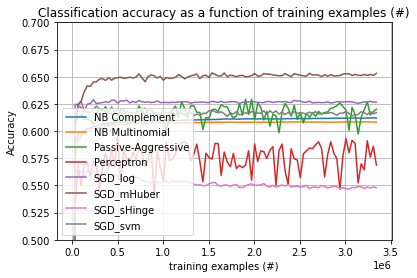

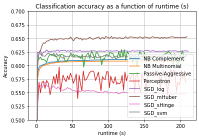

```python
def plot_accuracy(x, y, x_legend):
    """Plot accuracy as a function of x."""
    x = np.array(x)
    y = np.array(y)
    plt.title("Classification accuracy as a function of %s" % x_legend)
    plt.xlabel("%s" % x_legend)
    plt.ylabel("Accuracy")
    plt.grid(True)
    plt.plot(x, y)

rcParams["legend.fontsize"] = 10
cls_names = list(sorted(cls_stats.keys()))

# Plot accuracy evolution
plt.figure()
for _, stats in sorted(cls_stats.items()):
    # Plot accuracy evolution with #examples
    accuracy, n_examples = zip(*stats["accuracy_history"])
    plot_accuracy(n_examples, accuracy, "training examples (#)")
    ax = plt.gca()
    ax.set_ylim((0.5, 0.7))
plt.legend(cls_names, loc="best")

plt.figure()
for _, stats in sorted(cls_stats.items()):
    # Plot accuracy evolution with runtime
    accuracy, runtime = zip(*stats["runtime_history"])
    plot_accuracy(runtime, accuracy, "runtime (s)")
    ax = plt.gca()
    ax.set_ylim((0.5, 0.7))
plt.legend(cls_names, loc="best")
```

```python
for pred in list(predCls.keys()):
    print(pred, accuracy_score(y_val, predCls[pred]))
```

```
SGD_svm 0.6164406773916963
SGD_log 0.6264348144357498
SGD_mHuber 0.6521233728602752
SGD_sHinge 0.5455260223741244
Perceptron 0.568557611167406
NB Multinomial 0.6090730090519973
NB Complement 0.6104624957213978
Passive-Aggressive 0.6188028047296771
```

```python
for pred in list(predCls.keys()):
    print(pred, balanced_accuracy_score(y_val, predCls[pred]))
```

```
SGD_svm 0.45285683299296514
SGD_log 0.46027762766756924
SGD_mHuber 0.504868964456893
SGD_sHinge 0.4227226864551228
Perceptron 0.46977330137762874
NB Multinomial 0.43665167190735554
NB Complement 0.49179248722302304
Passive-Aggressive 0.5039572625037301
```

```python
for pred in list(predCls.keys()):
    print(pred, cohen_kappa_score(y_val, predCls[pred]))
```

```
SGD_svm 0.4026747005601584
SGD_log 0.42519959141653896
SGD_mHuber 0.47594803748724157
SGD_sHinge 0.32906846779513976
Perceptron 0.38425350783444856
NB Multinomial 0.3967155799044564
NB Complement 0.4441352853544229
Passive-Aggressive 0.4376759903852214
```

```python
for pred in list(predCls.keys()):
    for avg in ["micro", "macro", "weighted", None]:
        print(pred, avg, precision_score(y_val, predCls[pred], average=avg))
```

```
SGD_svm micro 0.6164406773916963
SGD_svm macro 0.5178706294685422
SGD_svm weighted 0.5641330829641468
SGD_svm None [0.60484654 0.40852181 0.46493034 0.45549779 0.65555668]
SGD_log micro 0.6264348144357498
SGD_log macro 0.5521740512011479
SGD_log weighted 0.5897472991721706
SGD_log None [0.66391603 0.48944687 0.46808987 0.46166455 0.67775294]
SGD_mHuber micro 0.6521233728602752
SGD_mHuber macro 0.5727699380766803
SGD_mHuber weighted 0.6194100299775922
SGD_mHuber None [0.66769102 0.49732719 0.48628353 0.49198191 0.72056603]
SGD_sHinge micro 0.5455260223741244
SGD_sHinge macro 0.46238016817141386
SGD_sHinge weighted 0.5309823341448597
SGD_sHinge None [0.71106836 0.28746214 0.30404064 0.34055121 0.66877849]
Perceptron micro 0.568557611167406
Perceptron macro 0.492888756221672
Perceptron weighted 0.58108073414927
Perceptron None [0.73419311 0.28543054 0.31059623 0.38741324 0.74681066]
NB Multinomial micro 0.6090730090519973
NB Multinomial macro 0.5275531310855814
NB Multinomial weighted 0.5716338374840387
NB Multinomial None [0.72567245 0.41921769 0.40427315 0.42030771 0.66829466]
NB Complement micro 0.6104624957213978
NB Complement macro 0.5171752608872093
NB Complement weighted 0.6087320783003398
NB Complement None [0.50387936 0.40833173 0.43283366 0.44988491 0.79094665]
Passive-Aggressive micro 0.6188028047296771
Passive-Aggressive macro 0.5097051313688111
Passive-Aggressive weighted 0.5861824557287494
Passive-Aggressive None [0.67391404 0.32659307 0.36882408 0.46197462 0.71721984]
```

```python
for pred in list(predCls.keys()):
    for avg in ["micro", "macro", "weighted", None]:
        print(pred, avg, recall_score(y_val, predCls[pred], average=avg))
```

```
SGD_svm micro 0.6164406773916963
SGD_svm macro 0.45285683299296514
SGD_svm weighted 0.6164406773916963
SGD_svm None [0.85861183 0.09097041 0.18293671 0.17592111 0.95584412]
SGD_log micro 0.6264348144357498
SGD_log macro 0.46027762766756924
SGD_log weighted 0.6264348144357498
SGD_log None [0.7761376  0.06048206 0.19533391 0.3561112  0.91332337]
SGD_mHuber micro 0.6521233728602752
SGD_mHuber macro 0.504868964456893
SGD_mHuber weighted 0.6521233728602752
SGD_mHuber None [0.84644741 0.12132386 0.2501246  0.40295111 0.90349785]
SGD_sHinge micro 0.5455260223741244
SGD_sHinge macro 0.4227226864551228
SGD_sHinge weighted 0.5455260223741244
SGD_sHinge None [0.5681499  0.21341847 0.20508348 0.3618974  0.76506419]
Perceptron micro 0.568557611167406
Perceptron macro 0.46977330137762874
Perceptron weighted 0.568557611167406
Perceptron None [0.57331779 0.34895224 0.21629703 0.47989707 0.73040237]
NB Multinomial micro 0.6090730090519973
NB Multinomial macro 0.43665167190735554
NB Multinomial weighted 0.6090730090519973
NB Multinomial None [0.70140196 0.08867704 0.09017568 0.41610019 0.88690349]
NB Complement micro 0.6104624957213978
NB Complement macro 0.49179248722302304
NB Complement weighted 0.6104624957213978
NB Complement None [0.88638592 0.09564709 0.18617618 0.53491797 0.75583528]
Passive-Aggressive micro 0.6188028047296771
Passive-Aggressive macro 0.5039572625037301
Passive-Aggressive weighted 0.6188028047296771
Passive-Aggressive None [0.77955636 0.2687292  0.32855719 0.2702554  0.87268817]
```

```python
for pred in list(predCls.keys()):
    for avg in ["micro", "macro", "weighted", None]:
        print(pred, avg, f1_score(y_val, predCls[pred], average=avg))
```

```
SGD_svm micro 0.6164406773916963
SGD_svm macro 0.43052607160109924
SGD_svm weighted 0.5462128505873862
SGD_svm None [0.70972759 0.14880471 0.26256259 0.25381462 0.77772085]
SGD_log micro 0.6264348144357498
SGD_log macro 0.4558263484627011
SGD_log weighted 0.5792466663653849
SGD_log None [0.71565417 0.10766029 0.27564229 0.40207579 0.77809919]
SGD_mHuber micro 0.6521233728602752
SGD_mHuber macro 0.5033367726518894
SGD_mHuber weighted 0.6159366268500293
SGD_mHuber None [0.74651739 0.195062   0.33033712 0.44303797 0.80172938]
SGD_sHinge micro 0.5455260223741244
SGD_sHinge macro 0.43722527785643556
SGD_sHinge weighted 0.5342130447530729
SGD_sHinge None [0.63162547 0.24496748 0.24494503 0.35089997 0.71368844]
Perceptron micro 0.568557611167406
Perceptron macro 0.47602347608356366
Perceptron weighted 0.5712304094371176
Perceptron None [0.64385845 0.31401113 0.25500817 0.42872425 0.73851539]
NB Multinomial micro 0.6090730090519973
NB Multinomial macro 0.4375213652835971
NB Multinomial weighted 0.5642945446119506
NB Multinomial None [0.71333082 0.14638854 0.14745957 0.41819337 0.76223453]
NB Complement micro 0.6104624957213978
NB Complement macro 0.46391742500149113
NB Complement weighted 0.589191548124486
NB Complement None [0.64251273 0.15498962 0.26036199 0.48873034 0.77299246]
Passive-Aggressive micro 0.6188028047296771
Passive-Aggressive macro 0.4987284256002936
Passive-Aggressive weighted 0.5924473250338465
Passive-Aggressive None [0.72289601 0.29484902 0.34752813 0.34101616 0.78735281]
```

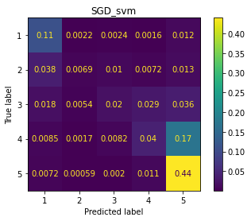

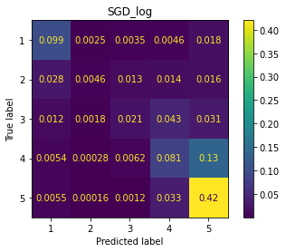

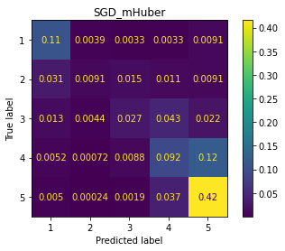

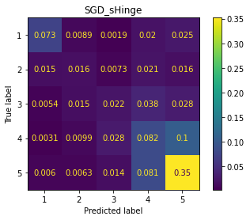

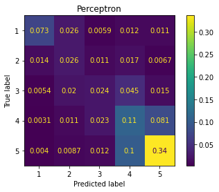

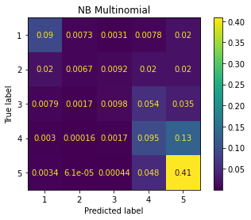

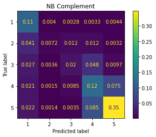

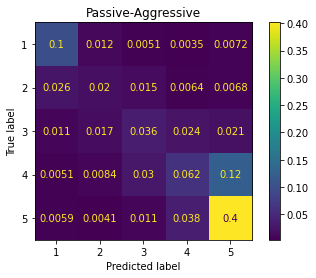

```python
for pred in list(predCls.keys()):
    cm = confusion_matrix(y_val, predCls[pred]
                            , normalize='all'
                            )
    disp = ConfusionMatrixDisplay(confusion_matrix=cm,
                                  display_labels=all_classes)
    disp.plot()
    plt.title(pred)
    plt.show()
```